# Forecasting the AZ, TX and FL epidemics

June 28, 2020

This entry will focus on Arizona, Florida and Texas and compare them to New York, Massachusetts, and New Jersey. Previous entries: https://eeholmes.github.io/CoV19/Updates.html

Like the northeast states, Arizona, Florida and Texas are now entering an epidemic phase where they have lost control of the virus. One of the difficulties for the US is that we cannot close state borders effectively. States can require quarantines but that is hard to enforce. We have seen over and over, how hotspots develop in locations that are draws from people from other regions. Travel into and out of US hotspots continually seeds infections in other areas and at some point enough seedings occur and enough take hold. Most disease seedings into a new area die out (the person doesn’t spread it to enough people), but a few become ‘super-spreader’ events–i.e. the person attends a few big social gatherings in that key pre-symptom window when they feel “ok” but have high virus load in their lungs and exhale that all over an enclosed space with many people. The epidemics in AZ, TX, and FL are certain to spread. There is constant travel into and out of those states.

The pattern of the epidemics in the northeast were multiple “seedings” of the disease due to travel in from Europe (particularly Italy) followed by “silent” (not much testing) spread throughout the community, and then a “flash” of very fast increases in cases, followed approximately two weeks later by very fast increases in deaths. The “flash” is just how exponential growth appears to us. When numbers are doubling at low levels, the increases are not noticeable and then once the numbers get bigger, they get big really really fast.

Florida, Arizona, and Texas are now showing a similar pattern. The initial lockdown was not successful (cases were not sufficiently driven down), once lockdown was lifted community spread resumed. Now they are in the “flash” phase where cases increase rapidly but deaths have not yet entered the flash phase.

Here is a plot of the 7-day average new cases per day per million people. The x-axis is days since the average per capita new cases per day reached 100. The dashed lines are NY, NJ and MA while the solid lines are AZ, FL, and TX. The AZ-TX-FL lines are quite similar in the rate of increase to the NY-NJ-MA lines. I put Sweden on just because I hear Sweden used as an example of a country that let the virus “take its own course” but that is entirely untrue. They imposed many mitigations to prevent a large epidemic occurring and rather staying with steady, manageable, levels. I also included Denmark to show a European country that controlled the virus and didn’t let it spread at all (most of Europe looks like this, exceptions being Belgium, UK, Spain, Italy, and Sweden)

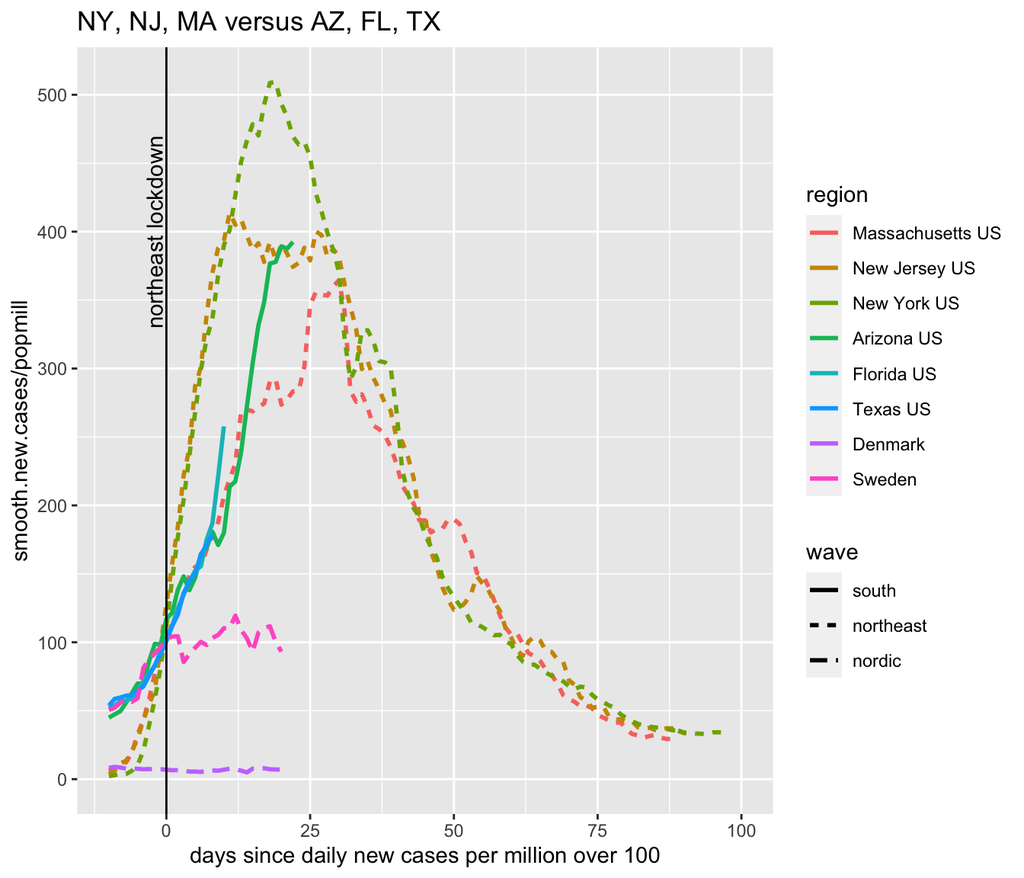

| region | death.per.100 |
| --- | --- |
| Essex New Jersey US | 0.2525736 |
| New York New York US | 1.3778423 |
| Suffolk Massachusetts US | 0.1248901 |

We can compare the 7-day average new cases per day per million people for the counties with NYC, Newark and Boston compared to the counties with Phoenix, Houston, and Miami. It would appear, at this early stage, that the latter cities are following more of Newark and Boston’s pattern rather than NYC.

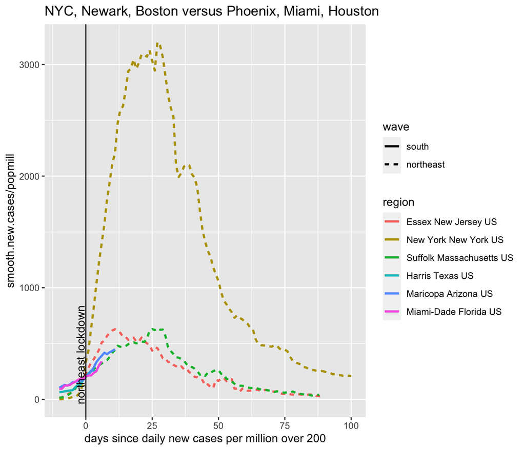

## Where are Arizona, Texas and Florida headed?

Using the patterns seen in the northeast outbreaks, we can make a guess at the mortalities and total cases to expect in the current outbreaks in the south/southwest. These estimates are probably a lower bound however. At around day 0 (when new cases per million were close to 100), NY, NJ, and MA employed a strict lockdown to stop their epidemics. AZ has gone well past that threshold without any severe mitigations. Only recently were cities in Texas allowed to impose their own stricter regulations to enforce social distancing. We have yet to see a cases where a city was not put into lockdown to stop a coronavirus epidemic once is got out of control. We are entering new territory here. Though Sweden is often touted as a country that did not employ mitigations, that’s not actually true. They didn’t lockdown like the rest of Europe, but certainly employed a variety of mitigations to reduce spread and have never entered a “flash” phase where they lost control of the epidemic.

### Mortality patterns

In the northeast, mortality started rising 7 (NY) to 14 (MA) days after cases started rising and it was only after daily new cases per million reached 100 (this is 10 on the graph because I divided new cases by 10) that the death curves started increasing. In NJ, this is really apparent. Reported deaths seem fine, fine, fine and then they started zooming up when daily new cases per million hit 200. Why the delay? First, people are on ventilators for a long time before dying and there are delays in death reporting. There are a few layers reporting (hospital, county, then state) before it appears on the state-wide lists. Some states are longer delays than others.

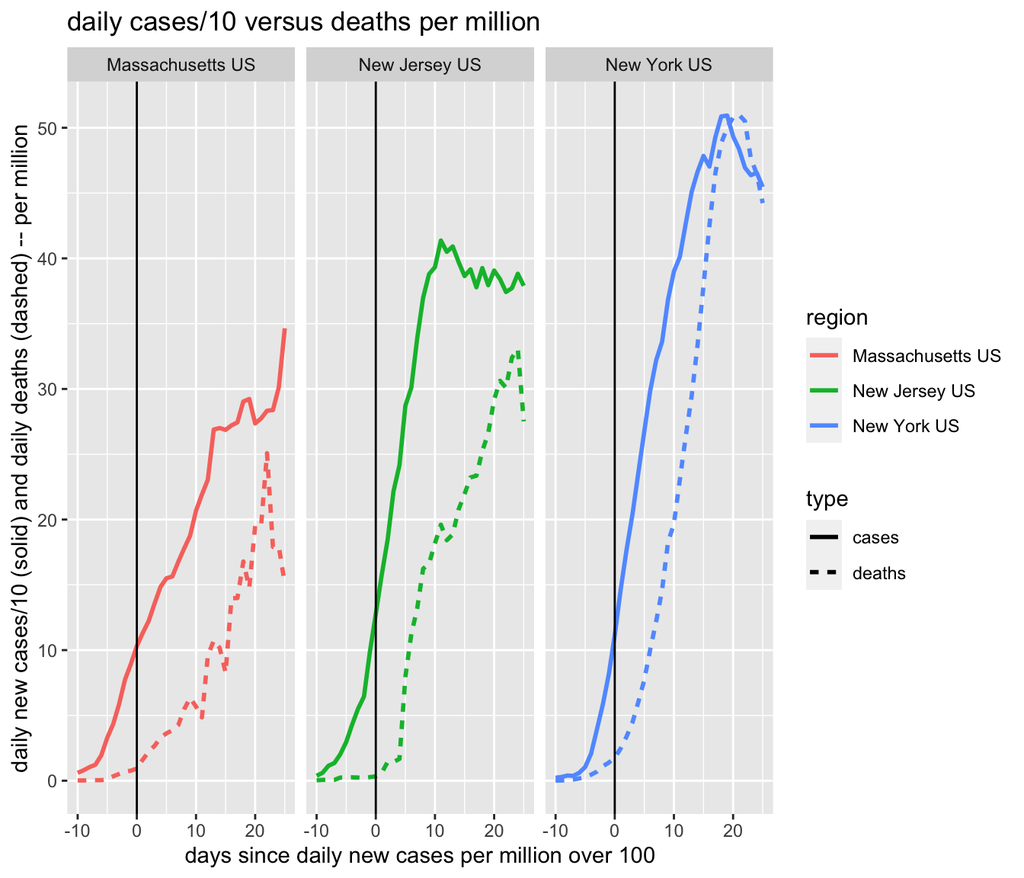

In Arizona, Florida and Texas, we are not yet seeing a rise in mortalities. We will eventually. The disease still has no cure. But for Arizona in particular, we are seeing an unusually long delay before the daily death curve begins to track the new cases curve. My guess is sometime in the next 7 days, it’ll start tracking. You can just begin to see that the Arizona mortality curve is start to go up (20 days after new cases per day hit 100 per million). In the northeast, we saw the same delay but much shorter. New cases were going up, but the deaths were not so there was a sense that “Maybe we got lucky. Maybe people won’t die here.” and then the deaths start piling up. We saw that in Germany too. For so long, people thought Germany was somehow special. Nope it just took longer.

No region has escaped 3-15% case fatality. We have the best information on the US case fatality rate from the northeast and eastern midwest where the first wave is now close to finished. CFR in the northeast was 7.68% and in the eastern midwest was 7%. The rest of the US regions are seeing 3.5-4% CFR.

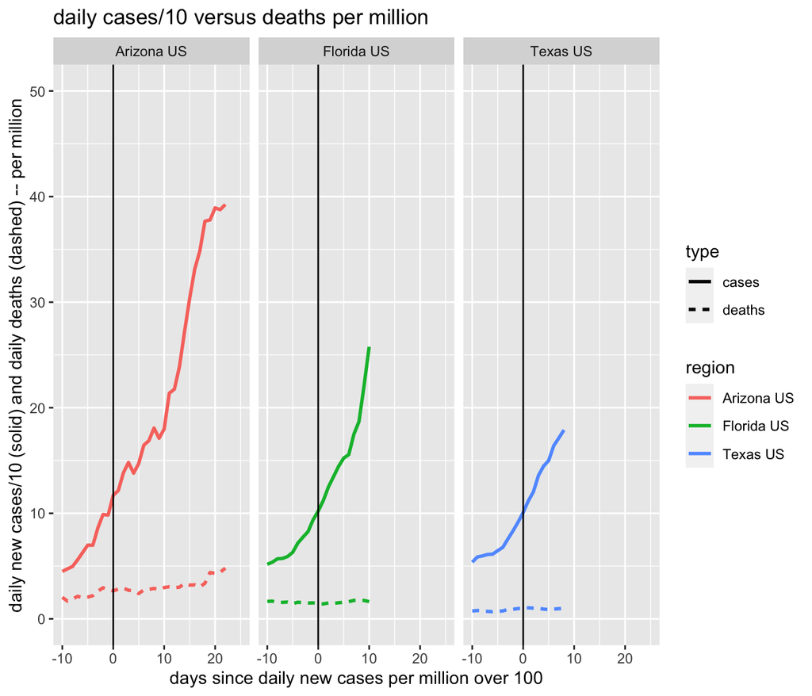

### Expected Mortality and Cases

Here are the current positive cases and deaths per 100 in the northeast. At the state level, the range is 1.5 to 2 for positive cases per 100 and 0.11 to 0.17 for deaths. For the urban centers, the range is 2.33 to 13.2 for positives and 0.12 to 1.38 for deaths. I’ll use these as my upper and lower ranges. But I am going to multiply the death number by 4/7 because the CFR in the northeast was around 7% whereas in AZ, TX and FL, it has been closer to 4%. This may be over-optimistic on my part to use 4/7ths.

| region | positive.per.100 | deaths.per.100 |
| --- | --- | --- |
| Massachusetts US | 1.573347 | 0.1168226 |
| New Jersey US | 1.923771 | 0.1682918 |
| New York US | 2.014659 | 0.1612455 |
| Essex New Jersey US | 2.339998 | 0.2525736 |
| Hudson New Jersey US | 2.875262 | 0.2153509 |
| New York New York US | 13.165912 | 1.3778423 |
| Suffolk Massachusetts US | 2.458493 | 0.1248901 |

The state estimates based on what NY, NJ, and MA experienced are 3, 4.2, 8.1 for AZ, FL, and TX times higher than current deaths on the low end and 4.4, 6.1, 11.7 times higher than current reported deaths on the high end.

| region | current.cases | min.cases | max.cases | current.deaths | min.deaths | max.deaths |
| --- | --- | --- | --- | --- | --- | --- |
| Arizona US | 70124 | 114519 | 146641 | 1600 | 4859 | 7000 |
| Florida US | 132545 | 337919 | 432703 | 3390 | 14338 | 20654 |
| Texas US | 145894 | 456206 | 584168 | 2388 | 19356 | 27884 |

The urban county estimates based on what NYC, Boston and Newark experienced are 5.4, 9.1, 4.3, 2 for Dallas, Houston, Phoenix and Miami times higher than current deaths on the low end and 59.1, 100.6, 47.7, 22.6 times higher than current reported deaths on the high end. Hmm, the high end is really skewed by the severity of what happened in NYC. Let’ pray that Dallas, Houston, Phoenix and Miami have Boston’s experience and not NYC’s.

| region | current.cases | min.cases | max.cases | current.deaths | min.deaths | max.deaths |
| --- | --- | --- | --- | --- | --- | --- |
| Dallas Texas US | 19595 | 61671 | 346990 | 351 | 1881 | 20750 |
| Harris Texas US | 29162 | 110292 | 620552 | 369 | 3364 | 37110 |
| Maricopa Arizona US | 42374 | 104959 | 590546 | 741 | 3201 | 35315 |
| Miami-Dade Florida US | 31562 | 63576 | 357710 | 947 | 1939 | 21392 |

Here are the predicted deaths in graphical form.

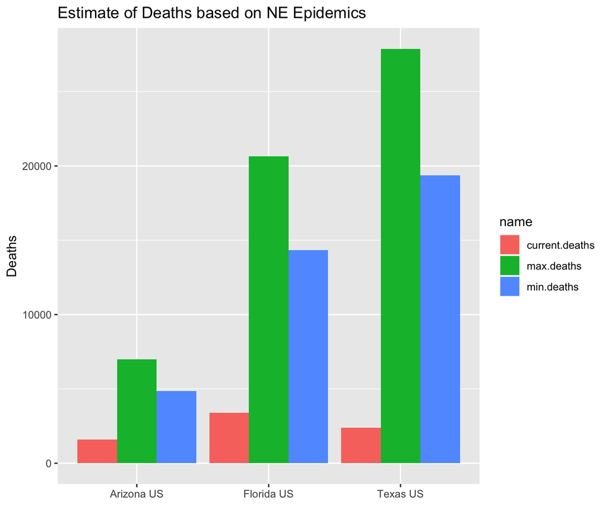